# Simulation of the sum of log-normally distributed catch rate estimates

Charles T T Edwards (NIWA, Wellington, New Zealand)

2020-09-18

```r
# libraries
library(ggplot2)
library(rstan)
library(bde)
```

Positive catch data per tow can be modelled using a log-normal pdf. For observer record $i$:
$$X_i \sim LN(\mu, \sigma)$$
where $\mu$ and $\sigma$ are the location and scale parameters for $\ln(X)$. The expected value and variance across observer records are:
$$E[X] = \exp(\mu + \sigma^2 / 2)$$
$$VAR[X] = \left(\exp\left(\sigma^2\right)-1\right)\cdot\exp\left(2\cdot \mu + \sigma^2\right)$$

Although we fit to tow-by-tow observer data to estimate $\mu$ and $\sigma$, we are interested in predicting the catch for aggregated effort data (i.e. not tow-by-tow). Specifically, for effort level $n$, we are required to predict the random variable:
$$Z = X_1 + X_2 + \dots + X_n$$
where each $X_i$ follows the log-normal distribution as defined above. Unfortunately the sum of log-normals does not follow a well defined probability distribution, although various approximations exist. The most common assumption is to assume that $Z$ also follows a log-normal distribution. If $X_i$ are i.i.d., then a good approximation for the first two moments of $\ln(Z)$ is:
$$\mu_{Z} = \ln\left(n \cdot \exp(\mu)\right) + \sigma^2 / 2 - \sigma^2_{Z} / 2$$
$$\sigma^2_{Z} = \ln\left((\exp\left(\sigma^2\right) - 1)\cdot \frac{1}{n} + 1\right)$$
which is known as the Fenton-Wilkinson method, and gives the familiar expectation:
$$E[Z] = \exp\left(\mu_z + \sigma^2_Z / 2\right) = \exp\left(\mu + \ln(n) + \sigma^2 / 2\right)$$

We can perform a simple exercise to validate this approximation for various values of $\sigma$, demonstrating that simulated values of $Z$ and $\sum{X_i}$ are similar.

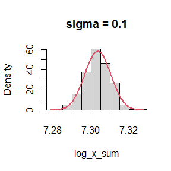

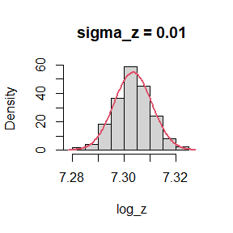

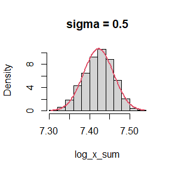

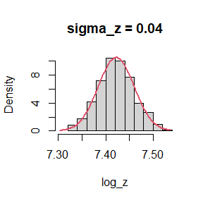

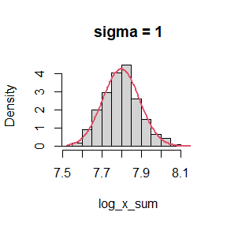

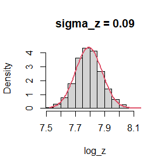

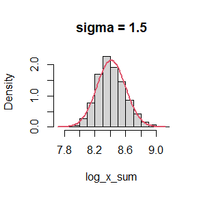

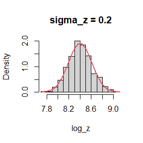

```r
iter <- 1000
n <- 200
mu <- 2
sigma <- c(0.1, 0.5, 1, 1.5)
sigma2 <- sigma^2

for (i in 1:length(sigma)) {

    log_x_sum <- numeric(iter)
    log_z <- numeric(iter)

    sigma_z <- sqrt(log((exp(sigma2[i]) - 1)/n + 1))
    mu_z <- log(n * exp(mu)) + sigma2[i]/2 - sigma_z^2/2

    # distribution of simulated values
    for (j in 1:iter) {
        log_x_sum[j] <- log(sum(rlnorm(n, mu, sigma[i])))
        log_z[j] <- log(rlnorm(1, mu_z, sigma_z))
    }

    xlims <- range(log_x_sum, log_z)
    hist(log_x_sum, probability = TRUE, main = paste("sigma =", sigma[i]), xlim = xlims)
    curve(dnorm(x, mean(log_x_sum), sd(log_x_sum)), col = 2, lwd = 2, add = TRUE, from = min(xlims),
        to = max(xlims))
    hist(log_z, probability = TRUE, main = paste("sigma_z =", round(sigma_z, 2)), xlim = xlims)
    curve(dnorm(x, mean(log_z), sd(log_z)), col = 2, lwd = 2, add = TRUE, from = min(xlims), to = max(xlims))
}
```

# Posterior predictive simulation

To illustrate how a simulation approach is used for posterior prediction of the observed data, we construct a simple example.

First we define a model that can estimate the parameters $\mu$ and $\sigma$ from log-normal data. Assuming $n$ samples generated from known values:
$$X_i \sim LN(\mu, \sigma)$$
we are required to estiamte $\hat{\mu}$ and $\hat{\sigma}$, and then use these estimates to generate values for $Z = \sum_n{X_i}$ using posterior predictive simulation.

```r
mdl <- "functions {

            real calc_sigma_z(real mu, real sigma, int n) {

                return sqrt(log((exp(square(sigma)) - 1) / n + 1));
            }

            real calc_mu_z(real mu, real sigma, int n) {

                real sigma_z = calc_sigma_z(mu, sigma, n);

                return log(n * exp(mu)) + square(sigma) / 2 - square(sigma_z) / 2;
            }
        }
        data{
            int<lower=1> n;
            vector[n] x;
        }
        transformed data {

            real x_sum = sum(x);
        }
        parameters{
            real mu;
            real<lower=0> sigma;
        }
        model{
            x ~ lognormal(mu, sigma);
        }
        generated quantities {

            vector[n] x_sim;
            vector[n] x_hat;

            real x_sim_sum;
            real x_sim_agg;

            real x_hat_sum;
            real x_hat_agg;

            real sigma_z = calc_sigma_z(mu, sigma, n);
            real mu_z    = calc_mu_z(mu, sigma, n);

            real D1[2] = { 0.0, 0.0 };
            real D2[2] = { 0.0, 0.0 };

            // expected and simulated values per record
            for (i in 1:n) {
                x_hat[i] = exp(mu + square(sigma) / 2);
                x_sim[i] = lognormal_rng(mu, sigma);
            }

            // sum expected and simulated values per record
            x_hat_sum = sum(x_hat);
            x_sim_sum = sum(x_sim);

            // expected and simulated values for summed data
            x_hat_agg = exp(mu_z + square(sigma_z) / 2);
            x_sim_agg = lognormal_rng(mu_z, sigma_z);

            // discrepancy for sum of simulations
            D1[1] = x_sum     - x_hat_sum;
            D1[2] = x_sim_sum - x_hat_sum;

            // discrepancy for simulation of sums
            D2[1] = x_sum     - x_hat_agg;
            D2[2] = x_sim_agg - x_hat_agg;

        }
        \n"

cat(mdl, file = "modelLogNormal.stan")

mdl <- stan_model("modelLogNormal.stan")

# generate data
set.seed(100)
n = 200
mu = 2
sigma = 1
x = rlnorm(n, mu, sigma)

# fit model
mdl.fit <- sampling(mdl, init = function() list(mu = mu, sigma = sigma), chains = 1, iter = 1000)
```

We first compare the model estimated values with the input parameter values used to simulate the data, and find them to be similar:

```r
# compare model estimates with data
mean(log(x))
```

```
#> [1] 2.007027
```

```r
summary(mdl.fit)$summary["mu", "mean"]
```

```
#> [1] 2.010075
```

```r
sd(log(x))
```

```
#> [1] 0.9130661
```

```r
summary(mdl.fit)$summary["sigma", "mean"]
```

```
#> [1] 0.9227245
```

The distribution of $E[X]$ and $SD[X]$ (taken across $n$ observations) also matches the input data:

```r
# compare simulated values with data
x_sim <- extract(mdl.fit, "x_sim")[[1]]

x_sim_mean <- apply(x_sim, 1, mean)
x_sim_sd <- apply(x_sim, 1, sd)
```

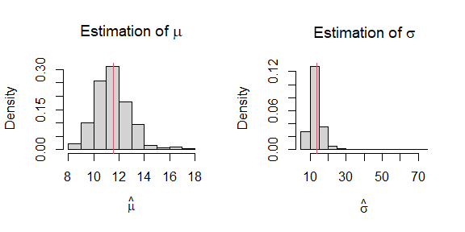

Next we validate our ability to simulate $Z = \sum{X_i}$, using the notation $\tilde{z}$ and $\tilde{x}$ to represent model predicted values.

```r
# distribution of summed values
x_sim_sum <- extract(mdl.fit, "x_sim_sum")[[1]]
x_sim_agg <- extract(mdl.fit, "x_sim_agg")[[1]]

x_hat_sum <- extract(mdl.fit, "x_hat_sum")[[1]]
x_hat_agg <- extract(mdl.fit, "x_hat_agg")[[1]]
```

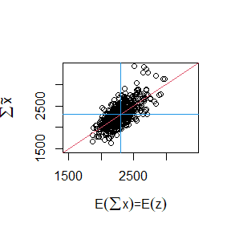

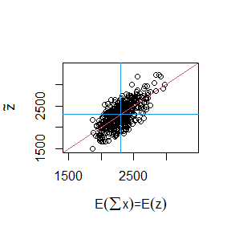

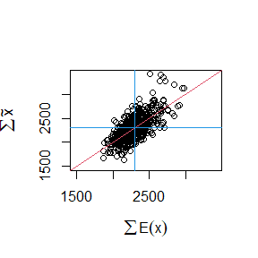

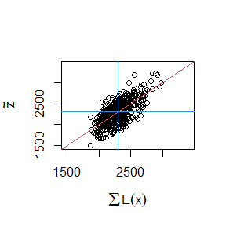

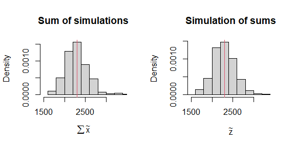

Distribution of simulated values around input data

Finally, model performance is checked using the discrepancy statistics: $T(\tilde{z},p) = \tilde{z}_p - \hat{z}_p$ and $T(z,p) = z - \hat{z}_p$; which represent the residual values of the observed and simulated data around the estimated expectation. Posterior predictive p-values are also shown, which should be close to 0.5 if the model is performing well.

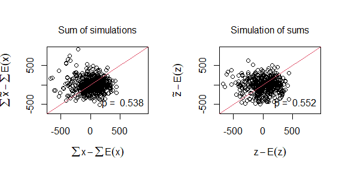

# Sampling from the approximate posterior

In some cases, a full MCMC will not be performed. Instead, parameters might be estimated using maxium penalised likelihood, or equivalently, the maximum a posteriori density (MAP), which finds the mode of the posterior distribution. Since stan uses the log-posterior density to perform it’s minimisation, generation of the Hessian matrix does not lead directly to the covariance matrix for the estimated parameters. Remembering that likelihood theory predicts that any parameter estimate is asymptotically normally distributed around it’s true value, the mode and mean of the log-posterior are equivalent. The Hessian matrix provides the variance, and samples can be simulated and then back-transformed onto the natural scale, giving a distribution of samples that approximates the posterior. It is then possible to calculate the mean and quantiles from that approximate distribution.

We show here that the approximation performs well, even for data that have been simulated using posterior prediction.

```r
# compare with MAP output
mdl.fit.map <- map(optimizing(mdl, init = function() list(mu = mu, sigma = sigma), hessian = TRUE,
    draws = 10000), pars = c("mu_z", "sigma_z", "x_hat_sum", "x_sim_sum", "x_sim_agg"), dims = list(list(0)))
```

```
#> [1] "MAP estimates"
#>               mean          sd       2.5%        50%      97.5%
#> mu_z    7.71688481 0.076308538 7.56875821 7.71808295 7.86971169
#> sigma_z 0.08025184 0.005967005 0.06982002 0.08021032 0.09301732
#> [1] "MCMC estimates"
#>               mean          sd      2.5%        50%      97.5%
#> mu_z    7.73184463 0.083069559 7.5845338 7.73428115 7.89909832
#> sigma_z 0.08200285 0.006336667 0.0717755 0.08142774 0.09669405
```

```
#> [1] "MAP estimates"
#>               mean       sd     2.5%      50%    97.5%
#> x_hat_sum 2253.196 173.7096 1942.355 2255.872 2626.799
#> x_sim_sum 2269.806 255.9968 1811.877 2242.233 2812.039
#> x_sim_agg 2287.194 252.0356 1823.786 2243.047 2801.825
#> [1] "MCMC estimates"
#>               mean       sd     2.5%      50%    97.5%
#> x_hat_sum 2295.535 193.7191 1974.044 2292.744 2706.561
#> x_sim_sum 2296.245 278.3412 1825.139 2270.723 2881.477
#> x_sim_agg 2288.141 270.1502 1784.212 2269.101 2861.748
```